# Лабораторная работа № 13

Фильтр пакетов

Павличенко Родион Андреевич

1132246838@pfur.ru

Российский университет дружбы народов

2025-06-09

# Информация

## Докладчик

- Павличенко Родион Андреевич
- Cтудент
- Группа НПИбд-02-24
- Российский университет дружбы народов им. П. Лумумбы
- 1132246838@pfur.ru

# Выполнение лабораторной работы

## Получили полномочия администратора. Определили текущую зону по умолчанию и доступные зоны.

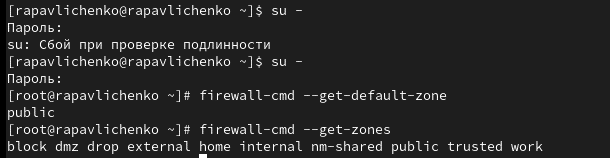

Определение текущих зон

## Посмотрели службы, доступные на нашем компьютере и определили доступные службы в текущей зоне

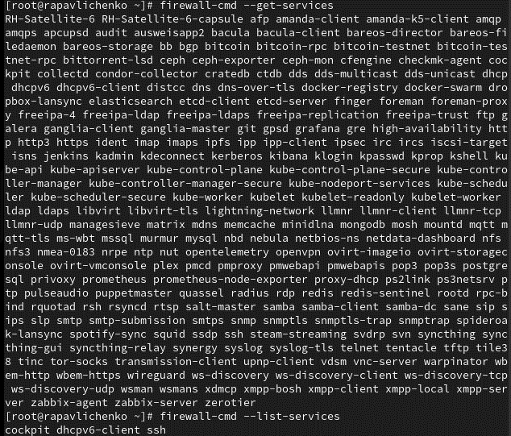

Просмотр служб

## Сравнили результаты вывода информации при использовании команды firewall-cmd –list-all и команды firewall-cmd –list-all –zone=public.

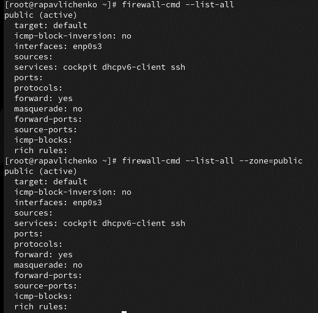

Сравнение двух команд для вывода информации

## Добавили сервер VNC в конфигурацию брандмауэра, проверили, что vnc-server добавился в конфигурацию.

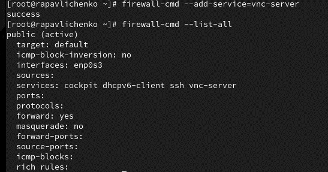

Работа с VNC сервером

## Перезапустили службу firewalld и проверили, есть ли vnc-server в конфигурации. Обратили внимание, что служба vnc-server больше не указана, так как мы ранее добавили ее, как запущенный сервис и при перезапуске автоматически не включалась.

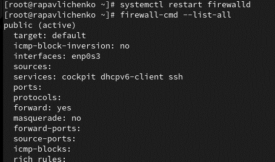

Проверка VNC сервера

## Добавили службу vnc-server ещё раз, но на этот раз сделали её постоянной. Проверили наличие vnc-server в конфигурации и увидили, что VNC-сервер не указан. Службы, которые были добавлены в конфигурацию на диске, автоматически не добавляются в конфигурацию времени выполнения.

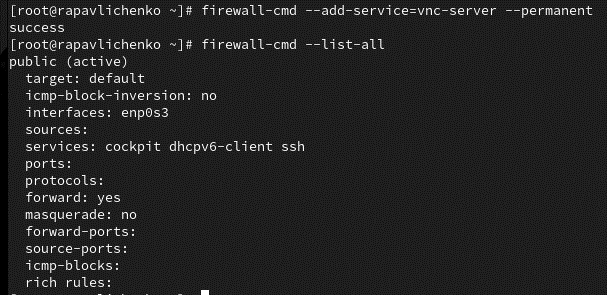

Работа с VNC сервером

## Перезагрузили конфигурацию firewalld и просмотрели конфигурацию времени выполнения, заметили, что служба vnc=server появилась

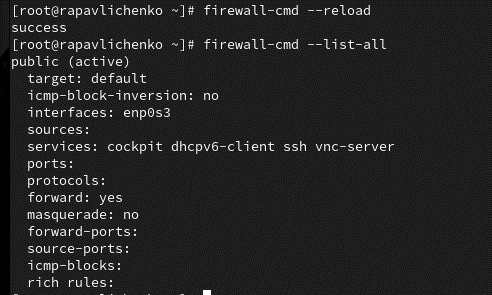

Перезагрузка firewalld и проверка службы

## Добавили в конфигурацию межсетевого экрана порт 2022 протокола TCP. Затем перезагрузили конфигурацию firewalld. Проверили, что порт был добавлен в конфигурацию.

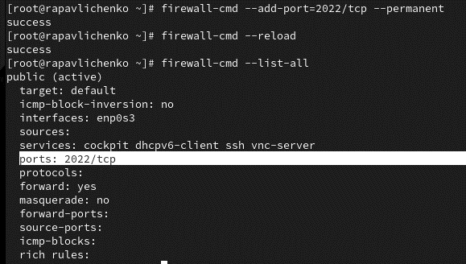

Добавление в конфигурацию порта 2022

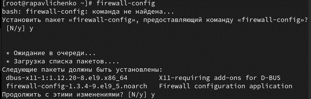

Запуск интерфейса GUI firewall-config

## Нажали выпадающее меню рядом с параметром Configuration . Открыли раскрывающийся список и выбрали Permanent . Это позволило сделать постоянными все изменения, которые мы вносили при конфигурировании. Выбрали зону public и отметили службы http, https и ftp, чтобы включить их

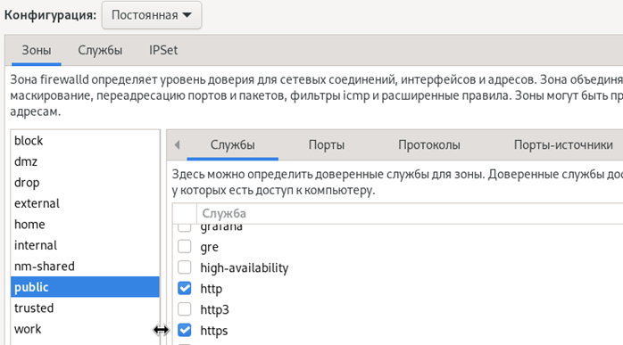

Работа в интерфейсе GUI firewall-config

## Выбрали вкладку Ports и на этой вкладке нажали Add . Ввели порт 2022 и протокол udp, нажали ОК , чтобы добавить их в список. Закрыли утилиту firewall-config.

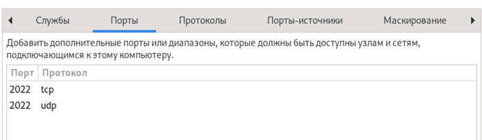

Работа в интерфейсе GUI firewall-config

## В окне терминала ввели firewall-cmd –list-all. Обратили внимание, что изменения, которые мы только что внесли, ещё не вступили в силу. Перегрузили конфигурацию firewall-cmd и список доступных сервисов, увидили, что изменения были применены

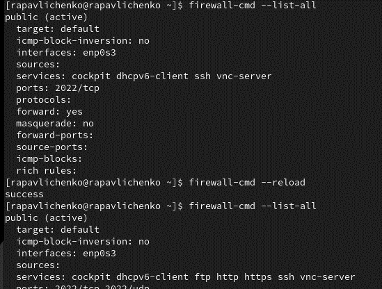

Перезагрузка конфигурации firewall-cmd и списка доступных сервисов

# Самостоятельная работа

## Создали конфигурацию межсетевого экрана, которая позволяет получить доступ к следующим службам: – telnet; – imap; – pop3; – smtp. Для службы telnet сделали это в командной строке.

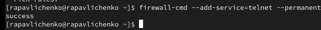

Создание конфигурации telnet

## Для служб imap, pop3, smtp сделали это в графическом интерфейсе

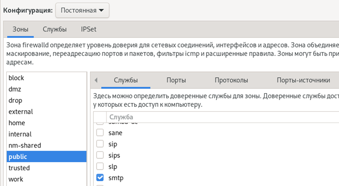

Создание конфигурации imap, pop3, smtp

## Убедились, что конфигурация является постоянной и будет активирована после перезагрузки компьютера. Сделали это, перезагрузив и проверив их наличие в списках.

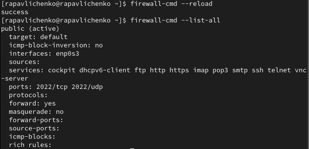

Проверка конфигурации